# index

Stats 220 Semester One 2023

Francesca Domanska

2023-04-27

## Introduction

This playlist is supposed to be a fun getting ready playlist. I designed it to be played when you’re getting ready with your friends to go out. I imagine girlfriends sitting and doing their hair and makeup together whilst listening to these fun songs. The music I chose was designed to make people getting ready feel fun and sexy.

One data manipulation I used to find relevant songs for my playlist was using filter(genre == “R&B/Soul” | genre == “Hip-Hop/Rap”). Filtering to only give me R&B or Rap music, helped me to find more nostalgic songs that really fit the fun and sexy vibe of the music I wanted. It also eliminated unwanted songs such as ones from musicals that did not suit the purpose of the playlist.

JSON nesting is really useful, especially when the aim is to have tidy data. Storing data in a csv file, means that you cannot have to more than one value in a cell, however with JSON, we can separate two or more values into their own rows. This would be specifically useful for data cells that may include more than one value. For example, in a song for, artistName you can have more than one person making the song, therefore using JSON you could separate them.

| trackName |
| --- |
| Factory Girl (Skit) |
| Girl |
| Girl |
| Girl |
| Girl |
| Girl |
| Girl |
| Girl |
| Girl (feat. KAYTRANADA) |
| Girl. |
| Go Girl (feat. Trina & Young Boss) |
| I Need a Girl, Pt. 1 (feat. Loon & Usher) |
| I Need a Girl, Pt. 2 [feat. Loon, Ginuwine & Mario Winans] |
| Nasty Girl (feat. Diddy, Nelly, Jagged Edge & Avery Storm) [2007 Remaster] |
| Oh Girl |
| U and Dat (Featuring T. Pain & Kandi Girl) |
| Who Dat Girl (feat. Akon) |

## Key features of my playlist

| artist | trackName | genre | track_length | track_min | feature | multi_artist |
| --- | --- | --- | --- | --- | --- | --- |
| G-Eazy | Factory Girl (Skit) | Hip-Hop/Rap | 13400 | 0.2233333 | 1 | no |
| Paul Wall | Girl | Hip-Hop/Rap | 278453 | 4.6408833 | 1 | no |
| Destiny’s Child | Girl | R&B/Soul | 206720 | 3.4453333 | 1 | no |
| Destiny’s Child | Girl | R&B/Soul | 224147 | 3.7357833 | 1 | no |
| Paul Wall | Girl | Hip-Hop/Rap | 278453 | 4.6408833 | 1 | no |
| Paul Wall | Girl | Hip-Hop/Rap | 345307 | 5.7551167 | 1 | no |
| The Time | Girl | R&B/Soul | 336240 | 5.6040000 | 1 | no |
| Destiny’s Child | Girl | R&B/Soul | 220493 | 3.6748833 | 1 | no |
| The Internet | Girl (feat. KAYTRANADA) | R&B/Soul | 416322 | 6.9387000 | 2 | yes |
| KnowMads | Girl. | Hip-Hop/Rap | 203943 | 3.3990500 | 1 | no |
| Pitbull | Go Girl (feat. Trina & Young Boss) | Hip-Hop/Rap | 229613 | 3.8268833 | 2 | yes |
| P. Diddy | I Need a Girl, Pt. 1 (feat. Loon & Usher) | R&B/Soul | 268800 | 4.4800000 | 2 | yes |
| P. Diddy | I Need a Girl, Pt. 2 [feat. Loon, Ginuwine & Mario Winans] | R&B/Soul | 285587 | 4.7597833 | 2 | yes |
| The Notorious B.I.G. | Nasty Girl (feat. Diddy, Nelly, Jagged Edge & Avery Storm) [2007 Remaster] | Hip-Hop/Rap | 286200 | 4.7700000 | 2 | yes |
| The Chi-Lites | Oh Girl | R&B/Soul | 216280 | 3.6046667 | 1 | no |
| E-40 | U and Dat (Featuring T. Pain & Kandi Girl) | Hip-Hop/Rap | 202720 | 3.3786667 | 1 | no |
| Flo Rida | Who Dat Girl (feat. Akon) | Hip-Hop/Rap | 200880 | 3.3480000 | 2 | yes |

```
## [1] 4.130939
```

```
## [1] 6.9387
```

```
## [1] 0.2233333
```

```
## [1] 6
```

```
## # A tibble: 2 × 2
##   multi_artist mean_duration
##   <chr>                <dbl>
## 1 no                    3.83
## 2 yes                   4.69
```

**The four key features of my playlist:**

**Graph from Part B**

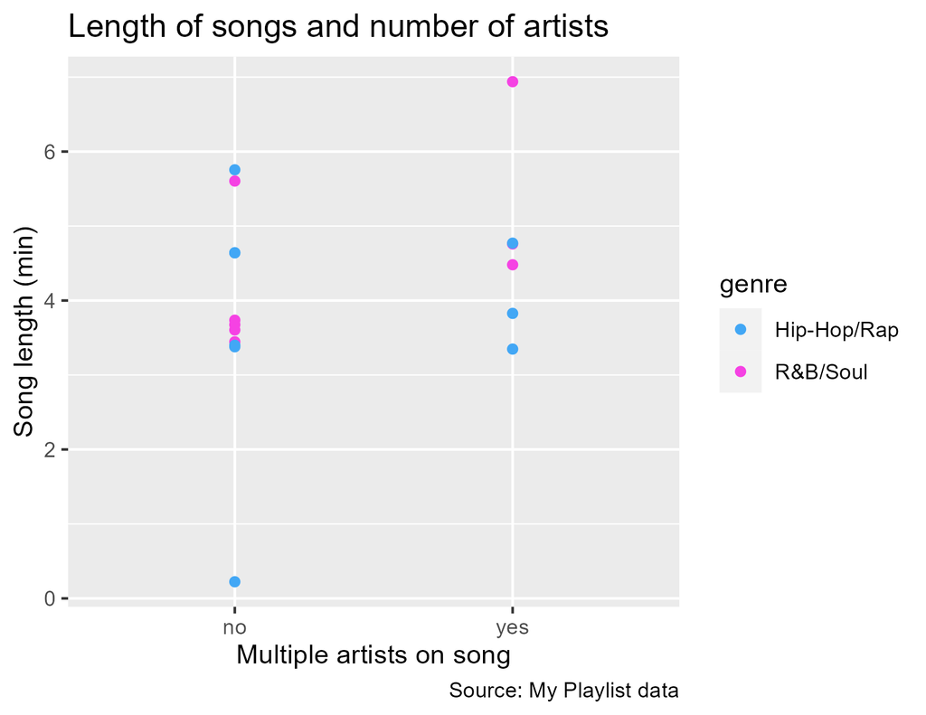

## SQL examples

**Example One**

```
SELECT *
FROM tbl_songs
WHERE genre LIKE '%R&B/Soul%';
```

This section is similar to:

```
my_playlist %>%
 filter(genre == "R&B/Soul")
```

Where all the data selected from my table is then filtered for when “R&B/Soul” appears in the genre column.

**Example Two**

```
SELECT * tracklength / 60000 AS trackmin
FROM tbl_songs;
```

This section is similar to:

```
song_data %>%
 mutate(track_min = track_length/60000)
```

Where all the data selected from the column track_length is mutated and divided by 60000 to produce a new column track_min.

## Learning reflection

An important idea I learned from Module 3 is the use of the mutate() function. I think the idea of being able to transform certain variables to make new ones that will be part of the new table is really useful. This is because the data we are given from the API is useful, however not always very usable or easy to interpret for an average music listener. For example, being able to use the mutate() function to create a new variable such as track_min, converting the music length from milliseconds to minutes, makes that data easier to read.

The way this Project demonstrates creativity is by the use of visualizing my data with a graph but also with by using CSS for the index page. With the graph, I decided to plot the length of songs in minutes and measure them by whether or not there were multiple artists on the song. I also filled the points by which genre the songs were (either R&B/Soul or Hip-Hop/Rap). I wanted to visualize and see if songs of a particular genre are longer.

I’ve also gone above the requirements and used CSS to improve the presentation of my index page. This is because I believe that increased visual interest keeps readers of the page more engaged. The CSS I used was mainly for the headings, helping the user navigate the page and find certain questions easier.

An aspect of Data Technologies that I would further like to explore is how to use SQL in more complex ways such as using them with relational databases. I think SQL is really useful and easy to understand (as it is quite similar to tidyverse). However, I think to improve my ability to build databases, it’s important that I can incorporate this sort of query building in a way that helps me store data efficiently.

## Apendix

```r
library(tidyverse)
library(jsonlite)

#Create initial playlist query
query <- "https://itunes.apple.com/search?term=girl&limit=200"
response <- fromJSON(query)
initial_playlist <- response$results

#Second version (not using)
#query <- "https://itunes.apple.com/search?term=ready&limit=200&media=music"
#response <- fromJSON(query)
#initial_playlist <- response$results %>%

#Creating my playlist and creating new columns using mutate() function
my_playlist <- initial_playlist %>%
  rename(artist = artistName,
         track_length = trackTimeMillis,
         genre = primaryGenreName) %>%
  select(artist, trackName, genre, track_length) %>%
  mutate(track_min = track_length/60000) %>%
  mutate(feature = str_count(trackName, "feat.") + 1)%>%
  mutate(multi_artist = ifelse(feature >= 2,"yes", "no")) %>%
  filter(genre == "R&B/Soul" | genre == "Hip-Hop/Rap") %>%
  arrange(trackName)

#Grouping features present or not to get average
my_playlist %>%
  group_by(multi_artist) %>%
  summarise(mean_duration = mean(track_min))

# Graphing song track time (min) and whether song has feature
my_playlist %>%
  ggplot() +
  geom_point(aes(x = multi_artist,
                y = track_min,
                color = genre)) +
                scale_color_manual(values=c("#42a7f5", "#f542e3")) +
  # Changing the captions and axis
  labs(title = "Length of songs and number of artists",
       x = "Multiple artists on song",
       y = "Song length (min)",
       caption = "Source: My Playlist data")

#Saving graph as png
ggsave("my_playlist.png")

#Saving my playlist as CSV
write_csv(my_playlist, "my_playlist.csv")

#Finding mean track length
mean_track_min <- my_playlist$track_min %>%
  mean()

#Finding max track length
max_track_min <- my_playlist$track_min %>%
  max()
print(mean_track_min)
```